# RE1 Randomized Experiments

ECON 474 Econometrics of Policy Evaluation

Today we replicate a few results from the first half of the randomized experiment from Thornton (2008). We are also going to add a balance table between treatment and control groups to indicate which variables should be conditioned on.

# 1 Preliminaries

To get started, we are going to load in the packages

- `tidyverse`
- `fixest`
- `cowplot`

The `cowplot` package is useful for plotting figures in grids. It might also be useful to load in the data too!

```r
library(tidyverse)
```

```r
library(fixest)
library(cowplot)

df = read_csv('C:/Users/johnj/Dropbox/Julian/Academia/UIUC/Semester 12 Spring 2023/ECON474sp23/Data/RE1 Thornton 2008 main sample.csv')
```

# 2 Balance Table

There first step in any treatment and control group comparison (whether a randomized experiment or otherwise) is to construct a balance table. The balance table tells us if the control group is a good approximation for the treated counterfactual **conditional on observable variables**. We cannot compare unobservable variables because they are not observed in the data set.

Below is the list of **CONTROL** variables for us to compare:

- `any` - treatment - any incentive
- `tinc` - treatment dosage - random incentive amount
- `distvct` - distance to VCT center
- `simaverage` - Simulated average distance from VCT to Home
- `tb` - Taken an HIV test before interview
- `male` - Male
- `age` - age
- `rumphi` - Located in the Rumphi district
- `balaka` - Located in the balaka district
- `mar` - married
- `educ2004` - pre-period level of education
- `land2004` - pre-period owned land
- `hiv2004` - pre-period HIV status
- `thinktreat` - Think treatment for HIV will be available in the next 5 years
- `hadsex12` - had sex in the last year
- `usecondom04` - used a condom in the last year

We will start by creating an object `vrbls` that contains the variable names.

```r
vrbls = c('any', # treatment - any incentive
          'tinc', # treatment dosage - random incentive amount
          'distvct', # distance to VCT center
          'simaverage', # Simulated average distance from VCT to Home
          'tb', # Taken an HIV test before interview
          'male', # Male
          'age',  # age
          'rumphi', # Located in the Rumphi district
          'balaka', # Located in the balaka district
          'mar',  # married
          'educ2004', # pre-period level of education
          'land2004', # pre-period owned land
          'hiv2004',  # pre-period HIV status
          'thinktreat', # Think treatment for HIV will be available in the next 5 years
          'hadsex12',  # had sex in the last year
          'usecondom04' ) # used a condom in the last year
```

Something to point out is that there are missing observations within the variables of interest.

**IMPORTANT**: when you are running your analysis, it is vital to compare the same observations across your different specifications. If you don’t maintain consistent observations, then it is impossible to know if your results are changing because of the specification or because the samples your a comparing are fundamentally different.

```r
df %>%
  select(c(vrbls)) %>%
  na.omit()
```

```
## # A tibble: 2,143 × 16
##      any   tinc distvct simaverage    tb  male   age rumphi balaka   mar educ2…¹
##    <dbl>  <dbl>   <dbl>      <dbl> <dbl> <dbl> <dbl>  <dbl>  <dbl> <dbl>   <dbl>
##  1     1 2.08      2.72       4.97     1     1    22      0      1     0       2
##  2     1 1.89      2.49       4.97     0     1    19      0      1     0       2
##  3     1 0.0946    1.84       4.97     0     0    53      0      1     0       0
##  4     1 0.946     2.22       4.97     1     0    50      0      1     1       8
##  5     1 0.567     2.91       4.97     0     0    21      0      1     1       0
##  6     1 1.89      2.23       4.97     0     1    21      0      1     0       3
##  7     1 1.89      3.02       4.97     0     0    24      0      1     1       0
##  8     1 0.946     2.21       4.97     0     0    44      0      1     1       0
##  9     1 0.189     2.67       4.97     0     1    16      0      1     0       5
## 10     1 0.946     4.10       4.97     0     0    30      0      1     1       5
## # … with 2,133 more rows, 5 more variables: land2004 <dbl>, hiv2004 <dbl>,
## #   thinktreat <dbl>, hadsex12 <dbl>, usecondom04 <dbl>, and abbreviated
## #   variable name ¹educ2004
```

```r
nrow(df)
```

```
## [1] 2812
```

Now, for the balance table. We are going to have our rows as the variables in `vrbls` with separate columns for: - treatment group averages - control group averages - differences in averages - p-value for difference significance

```r
bal_tab =
  df %>%
  select(vrbls) %>%
  group_by(any) %>%
  # Summarizing with means across all variables besides the group variable "any"
  summarise(across(vrbls[vrbls != 'any'], mean, na.rm = TRUE)) %>%
  # transposing the data by first pivoting longer then wider
  pivot_longer(!any, names_to = 'variable', values_to = 'D') %>%
  pivot_wider(values_from = D,
              names_from = any,
              names_prefix = 'D_') %>%
  # Reordering columns
  select(variable, D_1, D_0) %>%
  # Calculating differences
  mutate(diff = D_1 - D_0)
  # Adding p-vales requires running t-tests separately
```

We are going to manually add the p-values with `t.test()` by constructing a for loop.

```r
bal_tab$p_value = NA
for(v in vrbls[vrbls != 'any']){
  bal_tab$p_value[bal_tab$variable == v] = t.test(df[[v]] ~ df$any)$p.value
}
```

Now it is time to see which variables are statistically different between the treatment group (`D_1`) and the control group (`D_0`).

```r
bal_tab
```

```
## # A tibble: 15 × 5
##    variable        D_1     D_0      diff  p_value
##    <chr>         <dbl>   <dbl>     <dbl>    <dbl>
##  1 tinc         1.29    0       1.29     0
##  2 distvct      2.03    1.95    0.0825   1.42e- 1
##  3 simaverage   2.32    2.17    0.151    1.92e- 4
##  4 tb           0.172   0.212  -0.0401   2.87e- 2
##  5 male         0.461   0.471  -0.0101   6.58e- 1
##  6 age         33.7    32.1     1.64     6.01e- 3
##  7 rumphi       0.286   0.578  -0.292    1.29e-36
##  8 balaka       0.415   0.204   0.211    1.44e-26
##  9 mar          0.711   0.709   0.00206  9.21e- 1
## 10 educ2004     3.39    4.53   -1.14     1.55e- 9
## 11 land2004     0.755   0.659   0.0954   1.98e- 5
## 12 hiv2004      0.0624  0.0631 -0.000664 9.52e- 1
## 13 thinktreat   0.332   0.375  -0.0427   5.79e- 2
## 14 hadsex12     0.755   0.785  -0.0296   1.60e- 1
## 15 usecondom04  0.203   0.246  -0.0434   4.25e- 2
```

You should always include variables that are statistically distinguishable between treatment groups and control groups as control variables in your regressions. Note that this is not done in the paper.

# 3 Table 4: Incentive of Learning HIV Status Effects

```r
tab4_1_4 = feols(got ~ csw(any + tb + male + age + rumphi + balaka,
                           tinc,
                           I(tinc^2),
                           poly(distvct, 2)),
                 data = df, cluster = 'villnum')
tab4_5 = feols(got ~ any + tb + male + age + rumphi + balaka +
                           tinc +
                           I(tinc^2) + + simaverage, data = df, cluster = 'villnum')
```

Now check this out. Even though we have the correct number of observations, the coefficients do not precisely match the paper.

```r
etable(tab4_1_4, tab4_5)
```

```
##                          tab4_1_4.1          tab4_1_4.2          tab4_1_4.3
## Dependent Var.:                 got                 got                 got
##
## Constant         0.3909*** (0.0384)  0.3993*** (0.0373)  0.4035*** (0.0371)
## any              0.4320*** (0.0229)  0.3090*** (0.0261)  0.2168*** (0.0295)
## tb                 -0.0215 (0.0244)    -0.0235 (0.0237)    -0.0268 (0.0238)
## male               -0.0097 (0.0184)    -0.0129 (0.0182)    -0.0140 (0.0178)
## age               0.0019** (0.0006)  0.0020*** (0.0006)  0.0020*** (0.0006)
## rumphi          -0.1326*** (0.0291) -0.1497*** (0.0286) -0.1550*** (0.0288)
## balaka          -0.1201*** (0.0232) -0.1247*** (0.0239) -0.1231*** (0.0244)
## tinc                                 0.0919*** (0.0116)  0.2772*** (0.0357)
## tinc square                                             -0.0638*** (0.0112)
## poly(distvct)1
## poly(distvct)2
## simaverage
## _______________ ___________________ ___________________ ___________________
## S.E.: Clustered         by: villnum         by: villnum         by: villnum
## Observations                  2,812               2,812               2,812
## R2                          0.18069             0.20111             0.20717
## Adj. R2                     0.17893             0.19912             0.20490
##
##                          tab4_1_4.4              tab4_5
## Dependent Var.:                 got                 got
##
## Constant         0.3934*** (0.0359)  0.4287*** (0.0395)
## any              0.2189*** (0.0294)  0.2163*** (0.0296)
## tb                 -0.0244 (0.0237)    -0.0257 (0.0237)
## male               -0.0140 (0.0177)    -0.0139 (0.0177)
## age              0.0020*** (0.0006)  0.0020*** (0.0006)
## rumphi          -0.1453*** (0.0284) -0.1501*** (0.0288)
## balaka          -0.1122*** (0.0256) -0.1043*** (0.0268)
## tinc             0.2769*** (0.0356)  0.2773*** (0.0362)
## tinc square     -0.0638*** (0.0111) -0.0638*** (0.0112)
## poly(distvct)1    -1.425** (0.4521)
## poly(distvct)2     0.9621* (0.4709)
## simaverage                             -0.0151 (0.0098)
## _______________ ___________________ ___________________
## S.E.: Clustered         by: villnum         by: villnum
## Observations                  2,812               2,812
## R2                          0.21199             0.20799
## Adj. R2                     0.20917             0.20545
## ---
## Signif. codes: 0 '***' 0.001 '**' 0.01 '*' 0.05 '.' 0.1 ' ' 1
```

Anyway… Let’s make our `etable()` a little prettier. I first like to construct a table dictionary object outside of the `etable()`, so I can add to it later on in the script in case I run additional specifications with different variables. It is okay to have variables in the dictionary object that are not in any of the regression put into the `etable()`.

```r
dict = c(got = 'Got HIV Result',
         any = 'Any Incentive',
         tinc = 'Amount of Incentive',
         tb = 'HIV Positive',
         male = 'Male',
         age = 'Age',
         rumphi = 'Rumphi District',
         balaka = 'Balaka District',
         simaverage = 'Simulate Avg. Distance',
         distvct = 'Distance to VCT (km)',
         over = 'Over 1.5 km',
         villnum = 'Village')
```

```r
etable(tab4_1_4, tab4_5,
       se.below = TRUE,
       dict = dict,
       fitstat = ~ n + r2,
       poly_dict = c('', '^2'))
```

```
##                            tab4_1_4.1     tab4_1_4.2     tab4_1_4.3
## Dependent Var.:        Got HIV Result Got HIV Result Got HIV Result
##
## Constant                    0.3909***      0.3993***      0.4035***
##                            (0.0384)       (0.0373)       (0.0371)
## Any Incentive               0.4320***      0.3090***      0.2168***
##                            (0.0229)       (0.0261)       (0.0295)
## HIV Positive               -0.0215        -0.0235        -0.0268
##                            (0.0244)       (0.0237)       (0.0238)
## Male                       -0.0097        -0.0129        -0.0140
##                            (0.0184)       (0.0182)       (0.0178)
## Age                         0.0019**       0.0020***      0.0020***
##                            (0.0006)       (0.0006)       (0.0006)
## Rumphi District            -0.1326***     -0.1497***     -0.1550***
##                            (0.0291)       (0.0286)       (0.0288)
## Balaka District            -0.1201***     -0.1247***     -0.1231***
##                            (0.0232)       (0.0239)       (0.0244)
## Amount of Incentive                        0.0919***      0.2772***
##                                           (0.0116)       (0.0357)
## Amount of Incentive^2                                    -0.0638***
##                                                          (0.0112)
## poly(distvct)1
##
## poly(distvct)2
##
## Simulate Avg. Distance
##
## ______________________ ______________ ______________ ______________
## S.E.: Clustered           by: Village    by: Village    by: Village
## Observations                    2,812          2,812          2,812
## R2                            0.18069        0.20111        0.20717
##
##                            tab4_1_4.4         tab4_5
## Dependent Var.:        Got HIV Result Got HIV Result
##
## Constant                    0.3934***      0.4287***
##                            (0.0359)       (0.0395)
## Any Incentive               0.2189***      0.2163***
##                            (0.0294)       (0.0296)
## HIV Positive               -0.0244        -0.0257
```

[output cut: 10 more lines]

```
##                            (0.0356)       (0.0362)
## Amount of Incentive^2      -0.0638***     -0.0638***
##                            (0.0111)       (0.0112)
## poly(distvct)1             -1.425**
##                            (0.4521)
## poly(distvct)2              0.9621*
##                            (0.4709)
## Simulate Avg. Distance                    -0.0151
##                                           (0.0098)
## ______________________ ______________ ______________
## S.E.: Clustered           by: Village    by: Village
## Observations                    2,812          2,812
## R2                            0.21199        0.20799
## ---
## Signif. codes: 0 '***' 0.001 '**' 0.01 '*' 0.05 '.' 0.1 ' ' 1
```

# 4 Figure 3: Percantage Returning for HIV Results

Humans are visual creatures. If you can show something in a figure, then you should do that. Below we are not plotting the main results, but simple summary statistics.

If you are going to plot your results, then you need to use the Frisch-Waugh-Lovell theorem to account for your control variables.

## 4.1 Figure 3 Panel A

Panel A of figure 3 compares the percentage of people learning their HIV status across the incentive group (treatment) and the no incentive group (control). It also contains 95% confidence intervals for the estimates. We can take advantage of a dummy variable regression to obtain these values.

We are first going to create a variable that we will plot on the x-axis. `R` will alphabetize the label, so we need to order it as a `factor`.

```r
df =
  df %>%
  mutate(incentive = ifelse(any == 0, 'No Incentive', 'Incentive'))
df$incentive = factor(df$incentive, levels = c('No Incentive', 'Incentive'))
```

Now for the regression. To get the average values for the two groups, we will use the function `coef()` on the regression object. The confidence intervals are obtained with the function `confint()`, where the default value is a 95% confidence interval.

```r
fit3_a = lm(got ~ incentive - 1, data = df)
summary(fit3_a)
```

```
##
## Call:
## lm(formula = got ~ incentive - 1, data = df)
##
## Residuals:
##     Min      1Q  Median      3Q     Max
## -0.7908 -0.3414  0.2092  0.2092  0.6586
##
## Coefficients:
##                       Estimate Std. Error t value Pr(>|t|)
## incentiveNo Incentive 0.341424   0.017001   20.08   <2e-16 ***
## incentiveIncentive    0.790793   0.009023   87.64   <2e-16 ***
## ---
## Signif. codes:  0 '***' 0.001 '**' 0.01 '*' 0.05 '.' 0.1 ' ' 1
##
## Residual standard error: 0.4226 on 2810 degrees of freedom
## Multiple R-squared:  0.7421, Adjusted R-squared:  0.7419
## F-statistic:  4042 on 2 and 2810 DF,  p-value: < 2.2e-16
```

```r
coef(fit3_a)
```

```
## incentiveNo Incentive    incentiveIncentive
##             0.3414239             0.7907931
```

```r
confint(fit3_a)
```

```
##                           2.5 %    97.5 %
## incentiveNo Incentive 0.3080881 0.3747598
## incentiveIncentive    0.7731007 0.8084855
```

Now the goal is to put these numbers into a `ggplot()`, which requires a `data.frame` as an input. So, let’s create a `data.frame` from the regression output.

```r
df_fig3_a = data.frame(beta = coef(fit3_a),
                       group = factor(c('No Incentive', 'Incentive'),
                                      levels = c('No Incentive', 'Incentive'))) %>%
  # adding the confidence interval data
  bind_cols(confint(fit3_a))
df_fig3_a
```

```
##                            beta        group     2.5 %    97.5 %
## incentiveNo Incentive 0.3414239 No Incentive 0.3080881 0.3747598
## incentiveIncentive    0.7907931    Incentive 0.7731007 0.8084855
```

Now, time for a pretty plot:

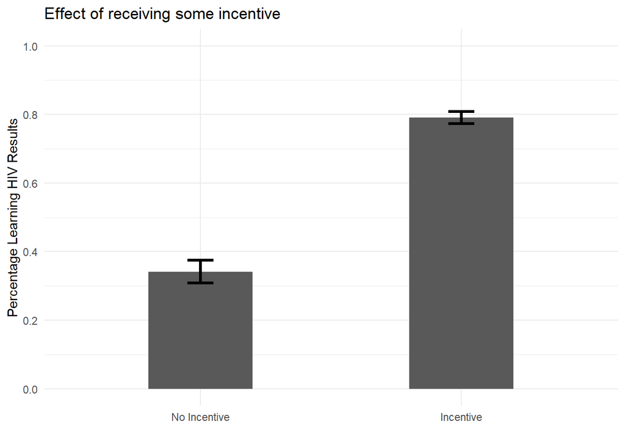

```r
fig3a =
  ggplot(df_fig3_a, aes(x = group, y = beta)) +
  geom_bar(stat = 'identity',
           width = 0.4) +
  geom_errorbar(aes(ymin = `2.5 %`, ymax = `97.5 %`),
                width = 0.1,
                linewidth = 1.1) +
  labs(x = '', y = 'Percentage Learning HIV Results',
       title = 'Effect of receiving some incentive') +
  # ylim(0, 1) +
  scale_y_continuous(breaks = seq(0, 1, by = 0.2), limits = c(0, 1)) +
  theme_minimal()
fig3a
```

## 4.2 Figure 3 Panel B

Panel B is effectively the same as panel A, which means that we can copy and paste our code from above. The only difference is that the groups are separated by incentive bins. We will use the `R` function `cut()` to separate the groups. `cut()` separates the data into left open, right closed intervals, which means we cannot obtain the interval (0, 0] for the no incentive group. Since no one received a negative incentive (having to pay for their results), we can do a bit of magic with negative numbers and relabeling the factor levels.

```r
df$inc_group =
  df$tinc %>% cut(breaks = c(-1, 0, 0.1, 0.2, 0.3, 0.5, 1, 1.5, 2.0, 2.5, 3.0))
levels(df$inc_group)
```

```
##  [1] "(-1,0]"    "(0,0.1]"   "(0.1,0.2]" "(0.2,0.3]" "(0.3,0.5]" "(0.5,1]"
##  [7] "(1,1.5]"   "(1.5,2]"   "(2,2.5]"   "(2.5,3]"
```

```r
levels(df$inc_group)[1] = '[0]'
```

From here, on out, it is basically copying and pasting while remembering to rename objects.

```r
# [Copy and paste this stuff]
fit3_b = lm(got ~ inc_group - 1, data = df)
summary(fit3_b)
```

```
##
## Call:
## lm(formula = got ~ inc_group - 1, data = df)
##
## Residuals:
##     Min      1Q  Median      3Q     Max
## -0.8725 -0.3414  0.1302  0.2274  0.6586
##
## Coefficients:
##                    Estimate Std. Error t value Pr(>|t|)
## inc_group[0]        0.34142    0.01680   20.32   <2e-16 ***
## inc_group(0,0.1]    0.62500    0.05580   11.20   <2e-16 ***
## inc_group(0.1,0.2]  0.65132    0.03387   19.23   <2e-16 ***
## inc_group(0.2,0.3]  0.65432    0.04640   14.10   <2e-16 ***
## inc_group(0.3,0.5]  0.70833    0.02570   27.56   <2e-16 ***
## inc_group(0.5,1]    0.77257    0.01740   44.40   <2e-16 ***
## inc_group(1,1.5]    0.84211    0.03030   27.80   <2e-16 ***
## inc_group(1.5,2]    0.86982    0.01855   46.90   <2e-16 ***
## inc_group(2,2.5]    0.87248    0.03421   25.50   <2e-16 ***
## inc_group(2.5,3]    0.84475    0.02822   29.94   <2e-16 ***
## ---
## Signif. codes:  0 '***' 0.001 '**' 0.01 '*' 0.05 '.' 0.1 ' ' 1
##
## Residual standard error: 0.4176 on 2802 degrees of freedom
## Multiple R-squared:  0.7489, Adjusted R-squared:  0.748
## F-statistic: 835.7 on 10 and 2802 DF,  p-value: < 2.2e-16
```

```r
df_fig3_b = data.frame(beta = coef(fit3_b),
                       group = factor(levels(df$inc_group),
                                      levels = levels(df$inc_group))) %>%
  bind_cols(confint(fit3_b))
```

And similarly:

```r
fig3b = ggplot(df_fig3_b, aes(x = group, y = beta)) +
  geom_bar(stat = 'identity', width = 0.4) +
  geom_errorbar(aes(ymin = `2.5 %`, ymax = `97.5 %`),
                width = 0.1) +
  labs(x = '', y = 'Percentage Learning HIV Results',
       title = 'Effect of the total amount of the incentive') +
  # ylim(0, 1) +
  scale_y_continuous(breaks = seq(0, 1, by = 0.2), limits = c(0, 1)) +
  theme_minimal()
```

Now to put together figure 3! For the sake of readability in an R Markdown, I am going to use the function `plot_grid()` from the `cowplot` package to put the figures on top of each other instead of side-by-side like the paper.

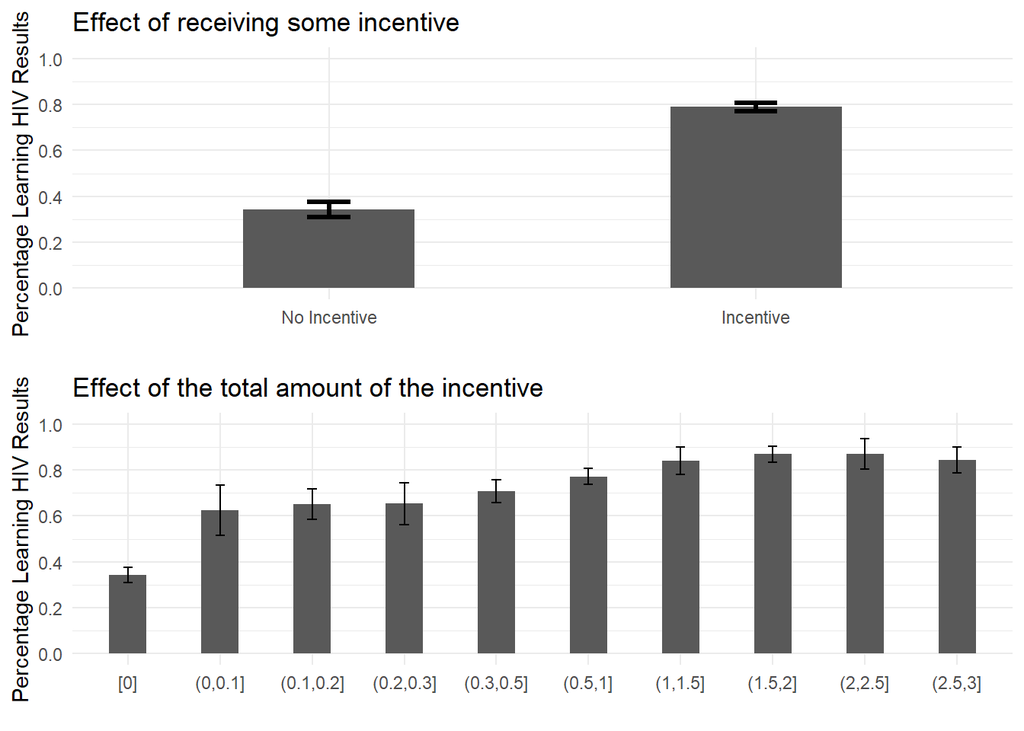

```r
plot_grid(fig3a, fig3b, ncol = 1)
```